# Analysis of scores on the ngs data

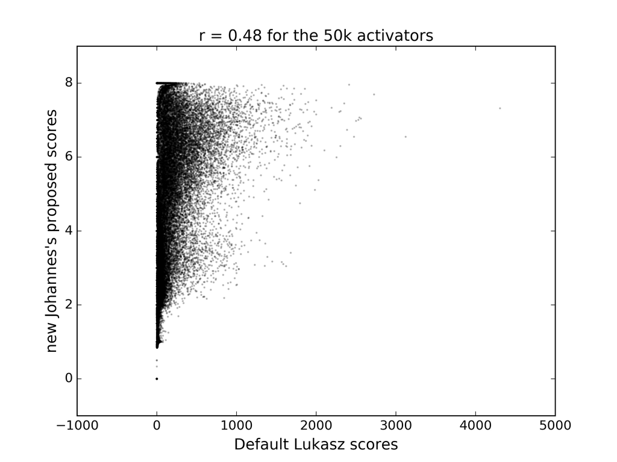

```python
import numpy as np
import pandas as pd
import matplotlib.pyplot as plt
from matplotlib import rc
from sklearn.neighbors import KernelDensity
from glob import glob
import re

'''
old_50k contains the ~50K selected activators. This file is >1 year old ("results_score_sorted_nonzeros3_10.csv").
new_1M should contain ~1.8M sequences ("ARG3_O1_O2.tsv", after clustering?). Since the number
of reads per bin are slightly different than in old_50k I map the 50K seqs into the new_1M file and compute Soeding's new score.
'''

old_50k = pd.read_csv('./results_score_sorted_nonzeros6_10.csv', delimiter='\t')
new_1M = pd.read_csv('./ARG3_O1_O2.tsv', delimiter='\t')

# Overcome any difference in the names of trhe indexes
for df in [old_50k, new_1M]:
    df.columns = np.insert(df.columns,1,'sequence')[1:]
    df.set_index('sequence', inplace=True)

# map old_50 sequences into the new_1M
ids = list(old_50k.index)
df = new_1M.loc[ids]

# calculate the "newest_score". I call it the "newest" because is newer than Lukasz's new score.
df['newest_score'] = ( 1.0 / df[['bg','bin1','bin2','bin3','bin4']].sum(axis=1) ) * ( np.sum( np.array([0,1,2,4,8]) * df[['bg','bin1','bin2','bin3','bin4']], axis=1) )

# scatter plot and correlation
x = df.score.fillna(0).values
y = df.newest_score.fillna(0).values

# How do newest and old scores correlate?
plt.scatter(x,y, c='k', s=1, alpha=0.2)
plt.title('r = '+'{:.2f}'.format(np.corrcoef(x,y)[0][1])+' for the 50k activators')
plt.xlabel('Default Lukasz scores', size=14)
plt.ylabel('new Johannes\'s proposed scores', size=14)
```

### Fitting the linear model with all available samples: 18

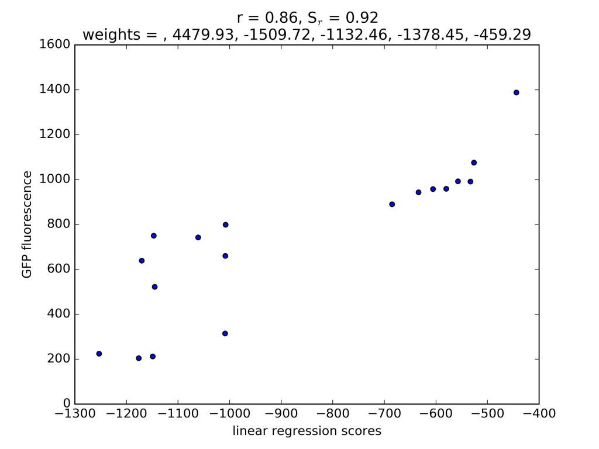

```python
# library to fit the linear model
from sklearn.linear_model import LinearRegression
from scipy.stats.mstats import spearmanr

# file containing all data for the 18 mutants
validation_df = pd.read_csv('./activity_measurements-for-18-peptide-seqs.tsv', delimiter='\t')
values_bins = validation_df[['background_number','bin1_number','bin2_number','bin3_number','bin4_number']]


# Normalize the values of the bins per sample
X = ( 1.0 / values_bins.sum(axis=1) ).reshape(-1,1) * values_bins.values
y = validation_df['GFP fluo'].values

# Find the optimal weights and use them to get the r and Sr
linear_model = LinearRegression().fit(X,y)
x = np.sum( linear_model.coef_ * X, axis=1)
r = np.sqrt( linear_model.score(X,y) )
Sr = spearmanr(np.sum([0,1,2,4,8] * X, axis=1),y)[0]; SR=r'S$_{r}$'

# plot sequence scores with fitted weights vs GFP fluorescence
weights = ', '.join(['{:.2f}'.format(i) for i in linear_model.coef_])
plt.scatter(x,y)
plt.xlabel('linear regression scores')
plt.ylabel('GFP fluorescence')
plt.title('r = {:.2f}, {} = {:.2f}\nweights = , '.format(r, SR, Sr) + weights)
```

### To avoid these weird negative numbers I can use a non-negative least-squares fitting

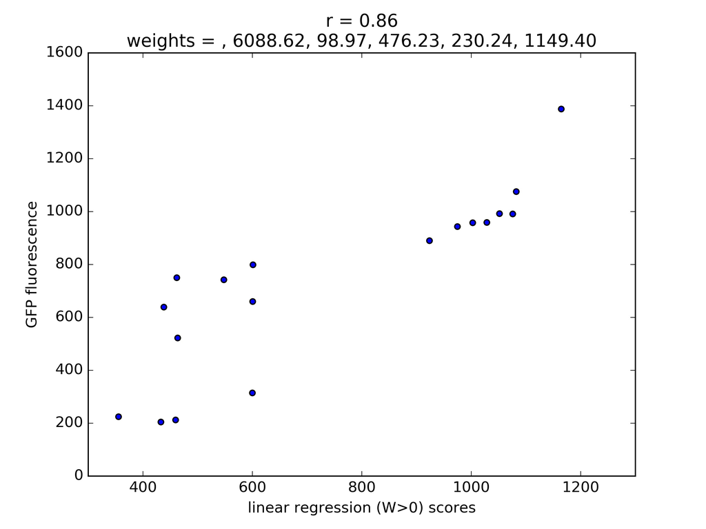

```python
# nnls: "https://docs.scipy.org/doc/scipy/reference/generated/scipy.optimize.nnls.html"
from scipy.optimize import nnls
weights, rnorm = nnls(X,y)
x_positive = np.sum( weights * X, axis=1)
r = np.corrcoef(x_positive, y)[0][1]
weights = ', '.join(['{:.2f}'.format(i) for i in weights])
plt.scatter(x_positive, y)
plt.xlabel('linear regression (W>0) scores')
plt.ylabel('GFP fluorescence')
plt.title('r = {:.2f}\nweights = , '.format(r) + weights)
```

### Still non-sense… backround has too much importance in these models. I keep it 0.

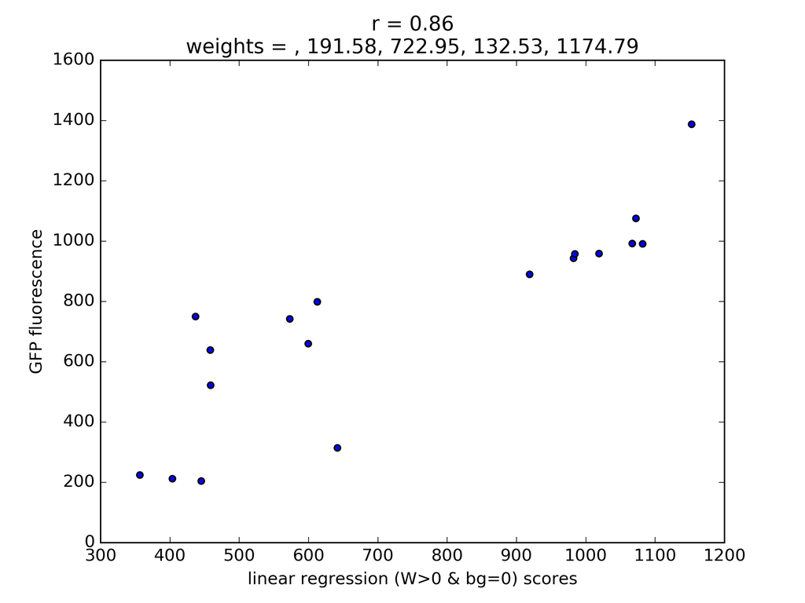

```python
# Same as above but with background weight set to 0
X_true = X[:,1:]
weights, rnorm = nnls(X_true,y)
x_positive = np.sum( weights * X_true, axis=1)
r = np.corrcoef(x_positive, y)[0][1]
weights_str = ', '.join(['{:.2f}'.format(i) for i in weights])
plt.scatter(x_positive, y)
plt.xlabel('linear regression (W>0 & bg=0) scores')
plt.ylabel('GFP fluorescence')
plt.title('r = {:.2f}\nweights = , '.format(r) + weights_str)
```

### Why is the 3rd bin less important than the 2nd? Should we merge bins2 and 3? or ’bin 3 may be under-represented compared to the other bins with only the weakest activators in that bin present in this validation set?

### Possible non-linear model? With 18 samples I can’t test it since with a degree=2 and 5 input features (bins) I end up with 21 potential variables in the polynomial equation. This is more than the number of samples (18) and I wold be overfitting… Is that true even when the features are not independent? Anyway, it would complicate the model…

```python
# Discarded!!
from sklearn.preprocessing import PolynomialFeatures
polynomial_equation = PolynomialFeatures(degree=2).fit_transform(X,y)
non_linear_model = LinearRegression().fit(polynomial_equation, y)
r = np.corrcoef(np.sum(a.coef_ * poly_model, axis=1), y)[0][1]
plt.scatter(np.sum(a.coef_ * poly_model, axis=1), y); plt.show()
#non_linear_model  = make_pipeline(PolynomialFeatures(degree), LinearRegression()).fit(X,y)
```

### Weights = [0,1,2,4,8] is a more coherent model…

## How are the scores distributed throughout the samples?

```python
# Density plot of scores on the same data
X_50k = old_50k[['background_number','bin1_number','bin2_number','bin3_number','bin4_number']].fillna(0)
X_50k = ( 1 / np.sum(X_50k, axis=1) ).reshape(-1,1) * X_50k

# Extracting or calculating different scores for the 50k set
old_k = old_50k.normalized_enrichment_slope_score
newest_k = np.sum( X_50k * [0,1,2,4,8], axis=1 )
linear_model_true_k = np.sum( weights * X_50k.ix[:,1:], axis=1 )

#To see where the 18 validation mutants fall within the distributions
gfp = validation_df.set_index('sequence')['GFP fluo']
gfp_norm = ( gfp-gfp.min() ) / ( gfp.max()-gfp.min() )
# points contain the score and gfp fluo
old_k_points = pd.concat([old_k,gfp_norm], axis=1, join='inner').values
newest_k_points = pd.concat([newest_k, gfp_norm],axis=1, join='inner').values
linear_model_true_k_points = pd.concat([linear_model_true_k, gfp_norm], axis=1, join='inner').values

# On the 50k activators
plt.figure()
plt.suptitle('On the 50k activators')
bw = [0.001, 0.4, 50]
for i, j in zip(['old_k', 'newest_k', 'linear_model_true_k'], range(1,5)):
    print i
    vals = vars()[i].values
    # Density estimation
    kde = KernelDensity(bandwidth=bw[j-1]).fit((vals.reshape(-1,1)))
    scale = np.max(vals)-np.min(vals)
    x_plot = np.linspace(np.min(vals)-scale*0.2, np.max(vals)*1.1, 200)
    prob = np.exp( kde.score_samples(x_plot.reshape(-1,1)) )
    # plot the distribution
    plt.subplot(2,2,j)
    plt.plot(x_plot, prob, lw=2)
    # plot the 18 mutants, their gfp gluorescence adapted to the y-scale
    scale_proba = np.max(prob) - np.min(prob)
    plt.scatter(vars()[i+'_points'][:,0], vars()[i+'_points'][:,1]*scale_proba, s=3)
    # aesthetics
    plt.title(i)
    [plt.xlabel('score') if j>1 else '']; plt.ylabel('freq')
    # To focus on a region where things happen
    if j==5:
        plt.xlim(-10,1000)
```

### Dots are the 18 mutants with their scores in the x-axis and their relative GFP-fluorescence in the y-axis. Dataset contains ~50k activators.

[figure not shown]

```python
# On the 1M samples
X_1M = ( 1.0 / new_1M[['bg','bin1','bin2','bin3','bin4']].sum(axis=1) ).reshape(-1,1) * \
        new_1M[['bg','bin1','bin2','bin3','bin4']].fillna(0)
# Get scores
new = new_1M.score
newest = np.sum( np.array([0,1,2,4,8]) * X_1M, axis=1)
new_short = new[new<=200]
linear_model_true = np.sum(weights * X_1M.drop('bg', axis=1), axis=1)
# 18 Mutants mapped on the new_1M new data, in case they are different from the other dataset
new_points = pd.concat([new, gfp_norm], axis=1, join='inner').values
newest_points = pd.concat([newest, gfp_norm], axis=1, join='inner').values
linear_model_true_points = pd.concat([linear_model_true, gfp_norm],axis=1, join='inner').values

# Since it takes too long I just plot the histograms
plt.figure()
plt.suptitle('On the 1M samples')
bins = [20,20,20,20]
for i, j in zip(['new', 'newest', 'linear_model_true'], range(1,5)):
    print i
    plt.subplot(2,2,j)
    vals = vars()[i].values
    y_hist,x_hist, _ = plt.hist(vals, bins=bins[j-1])
    plt.title(i)
    plt.ticklabel_format(axis='y', labelsize=10, style='sci', scilimits=(-2,2))
    [plt.xlabel('score') if j>1 else '']; plt.ylabel('freq')
    scale = np.max(vals) - np.min(vals)
    plt.xlim(np.min(vals)-scale*0.2, np.max(vals)+scale*0.2)
    scale_y_histo = np.max(y_hist) - np.min(y_hist)
    plt.scatter(vars()[i+'_points'][:,0], vars()[i+'_points'][:,1]*scale_y_histo, s=3)
```

### Again, the dots are the 18 mutants with their scores in the x-axis and the relative GFP-fluorescence in the y-axis. Dataset ~1.8M seqs sent on Jan, 2018 by Lukasz.

[figure not shown]

```
newest_k[newest_k>2].shape[0] *100.0 / newest_k.shape[0]
newest[newest>2].shape[0] *100.0 / newest.shape[0]
```

Newest_score: 74% have a score > 2 in the 50k activators set and 17% have a score > 2 in the 1.8M sequences set and

About the same proportions for the linear_model_true